# Momentum in R: Part 2

rbresearch

October 20, 2012

Many of the sites I linked to in the previous post have articles or papers on momentum investing that investigate the typical ranking factors; 3, 6, 9, and 12 month returns. Most (not all) of the articles seek to find which is the “best” look-back period to rank the assets. Say that the outcome of the article is that the 6 month look-back has the highest returns. A trading a strategy that just uses a 6 month look-back period to rank the assets leaves me vulnerable to over-fitting based on the backtest results. The backtest tells us nothing more than which strategy performed the best in the past, it tells us nothing about the future… duh!

Whenever I review the results from backtests, I always ask myself a lot of “what if” questions. Here are 3 “what if” questions that I would ask for this backtest are:

What if the strategy based on a 6 month look-back under performs and the 9 month or 3 month starts to over perform? What if the strategies based on 3, 6, and 9 month look-back periods have about the same return and risk profile, which strategy should I trade? What if the assets with high volatility are dominating the rankings and hence driving the returns? The backtests shown are simple backtests meant to demonstrate the variability in returns based on look-back periods and number of assets traded.

[output not shown]

```
## [1] "USD"
```

```
##  [1] "XLY" "XLP" "XLE" "XLF" "XLV" "XLI" "XLK" "XLB" "XLU" "EFA"
```

[output not shown]

```
##  [1] "XLY" "XLP" "XLE" "XLF" "XLV" "XLI" "XLK" "XLB" "XLU" "EFA"
```

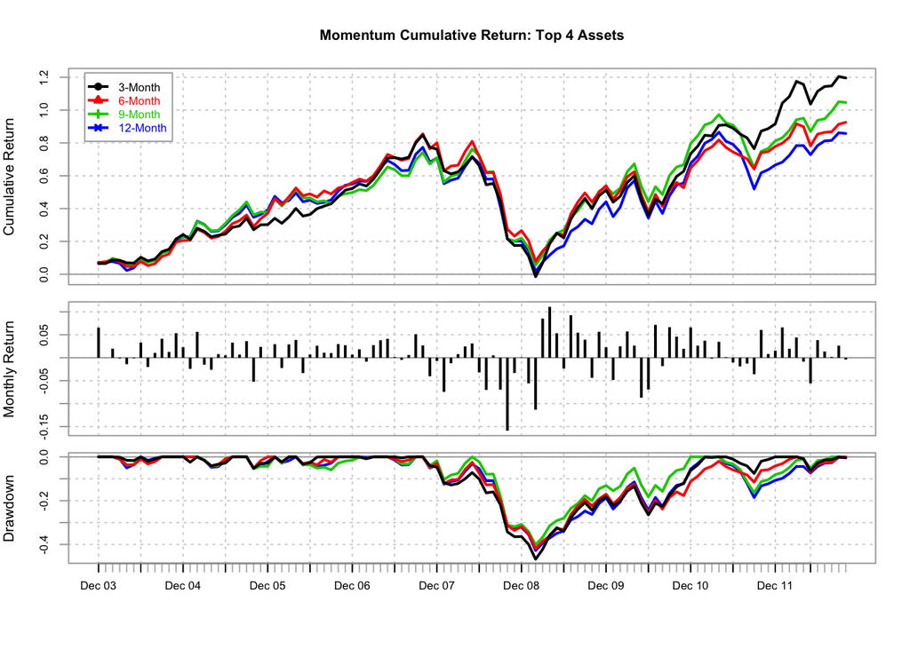

```
##                  3-Month  6-Month  9-Month 12-Month
## Observations    107.0000 107.0000 107.0000 107.0000
## NAs              15.0000  15.0000  15.0000  15.0000
## Minimum          -0.1590  -0.1446  -0.1603  -0.1397
## Quartile 1       -0.0123  -0.0129  -0.0138  -0.0138
## Median            0.0105   0.0132   0.0102   0.0120
## Arithmetic Mean   0.0083   0.0070   0.0076   0.0067
## Geometric Mean    0.0074   0.0061   0.0067   0.0058
## Quartile 3        0.0339   0.0364   0.0333   0.0333
## Maximum           0.1110   0.1014   0.0828   0.0833
## SE Mean           0.0041   0.0041   0.0041   0.0042
## LCL Mean (0.95)   0.0001  -0.0010  -0.0004  -0.0015
## UCL Mean (0.95)   0.0164   0.0151   0.0157   0.0150
## Variance          0.0018   0.0018   0.0018   0.0019
## Stdev             0.0425   0.0421   0.0420   0.0432
## Skewness         -0.8110  -0.7945  -0.9693  -0.8242
## Kurtosis          1.7940   1.0624   1.8023   0.9507
```

```
##    3-Month    6-Month    9-Month   12-Month
## 0.09223447 0.07624750 0.08363078 0.07192707
```

```
## [1] "End"
```